# Bank Customer Analysis

James Mckeown Nartey

2024-08-29

## Project Overview

Note: Ignore every code in gray if you are just a curios reader.

The objective of this project is to analyze data from 1,000 bank customers to gain insights into various aspects of their profiles, such as age, gender, account balances, credit information, loan duration, and purposes.

This analysis will provide valuable insights for the bank, helping them to:

- Tailor their financial products to meet the needs of different customer segments.
- Design targeted promotions based on customer demographics, such as age, occupation, and housing status.
- Understand the demographic profile of their clientele, enabling more personalized and effective marketing strategies.

Additionally, we will perform a risk analysis on the bank’s credit system to identify potential risk factors associated with lending. Such information is crucial for financial institutions, as it helps in optimizing lending strategies and minimizing potential losses.

To begin our analysis, we will first load the necessary libraries and import the data

```r
data <- read.csv("~/Downloads/german_credit_data.csv")
library(tidyverse)
```

```r
library(dplyr)
library(corrplot)
view(data)
```

Next, we will examine the summary statistics of the data. This step provides valuable insights into customer characteristics, such as average age, account balance, credit information, and employment status.

For example, the summary statistics will reveal the average age of the customers and the typical number of jobs they hold. From the data, we observe that 75% of the customers (up to the third quartile) are employed in at least two jobs. Additionally, we can see that some customers are not currently employed, while others are working up to three jobs.

```r
summary(data)
```

```
##        X              Age            Sex                 Job
##  Min.   :  0.0   Min.   :19.00   Length:1000        Min.   :0.000
##  1st Qu.:249.8   1st Qu.:27.00   Class :character   1st Qu.:2.000
##  Median :499.5   Median :33.00   Mode  :character   Median :2.000
##  Mean   :499.5   Mean   :35.55                      Mean   :1.904
##  3rd Qu.:749.2   3rd Qu.:42.00                      3rd Qu.:2.000
##  Max.   :999.0   Max.   :75.00                      Max.   :3.000
##    Housing          Saving.accounts    Checking.account   Credit.amount
##  Length:1000        Length:1000        Length:1000        Min.   :  250
##  Class :character   Class :character   Class :character   1st Qu.: 1366
##  Mode  :character   Mode  :character   Mode  :character   Median : 2320
##                                                           Mean   : 3271
##                                                           3rd Qu.: 3972
##                                                           Max.   :18424
##     Duration      Purpose
##  Min.   : 4.0   Length:1000
##  1st Qu.:12.0   Class :character
##  Median :18.0   Mode  :character
##  Mean   :20.9
##  3rd Qu.:24.0
##  Max.   :72.0
```

The purpose of this analysis, as the name suggests, is to understand the data structure and its various components. However, much more information can be gleaned from this basic analysis. For instance, the bank can analyze the age distribution of its customers to tailor its products to specific age groups. Similarly, insights into customer credit and other key variables can help the bank better align its offerings with the needs of different customer segments.

## Visualization

Among the various insights that can be derived from this data, I have chosen to focus on the summary statistics of age, credit amount, and loan duration. Additionally, I will visualize these variables using graphs to better understand their distribution and relationships

```r
summary(select(data,Age,Credit.amount,Duration))
```

```
##       Age        Credit.amount      Duration
##  Min.   :19.00   Min.   :  250   Min.   : 4.0
##  1st Qu.:27.00   1st Qu.: 1366   1st Qu.:12.0
##  Median :33.00   Median : 2320   Median :18.0
##  Mean   :35.55   Mean   : 3271   Mean   :20.9
##  3rd Qu.:42.00   3rd Qu.: 3972   3rd Qu.:24.0
##  Max.   :75.00   Max.   :18424   Max.   :72.0
```

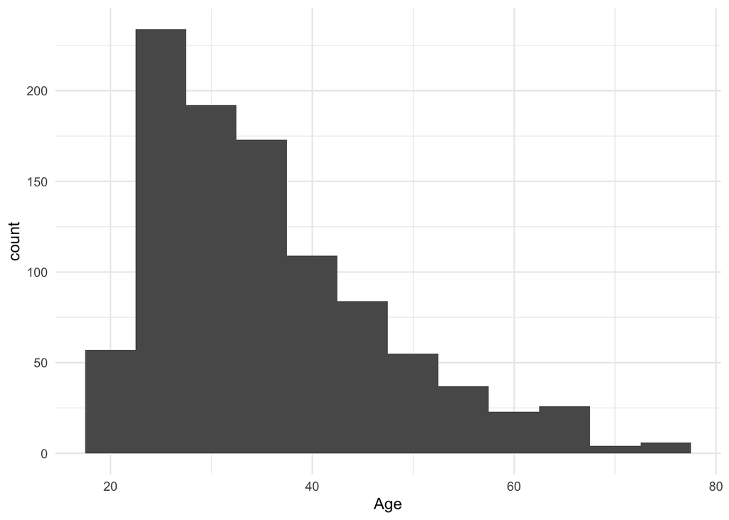

```r
ggplot(data,aes(x=Age))+geom_histogram(binwidth = 5)+theme_minimal()
```

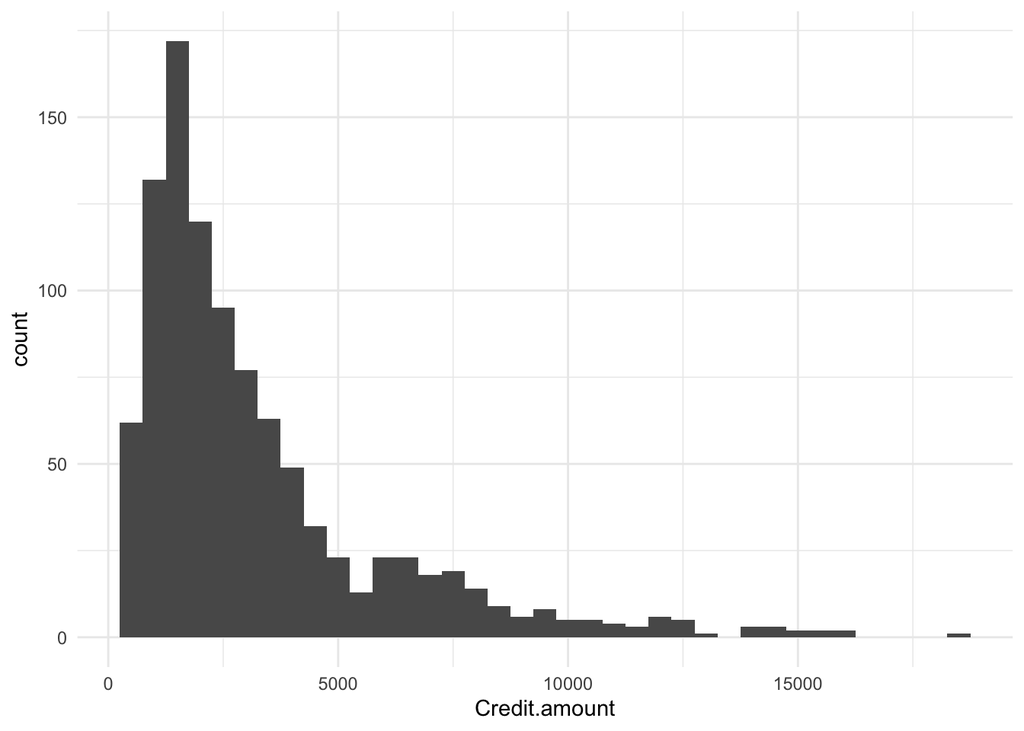

```r
ggplot(data,aes(x=Credit.amount))+geom_histogram(binwidth = 500)+theme_minimal()
```

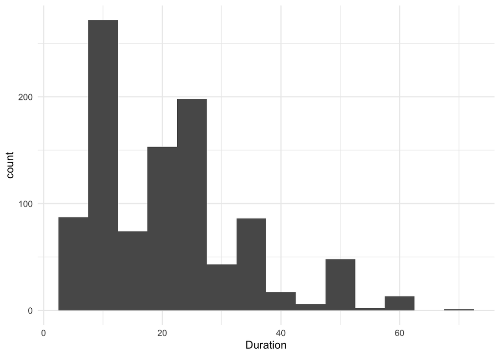

```r
ggplot(data,aes(x=Duration))+geom_histogram(binwidth = 5)+theme_minimal()
```

## Moving on

We can segment our customers based on various variables to gain a clearer understanding of their characteristics and behaviors Below is the segmentation based on all other variables. Note: Count stands for number of Customers.

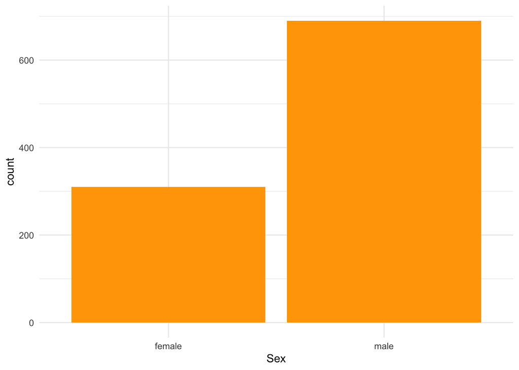

```r
ggplot(data, aes(x = Sex)) + geom_bar(fill="orange") + theme_minimal()
```

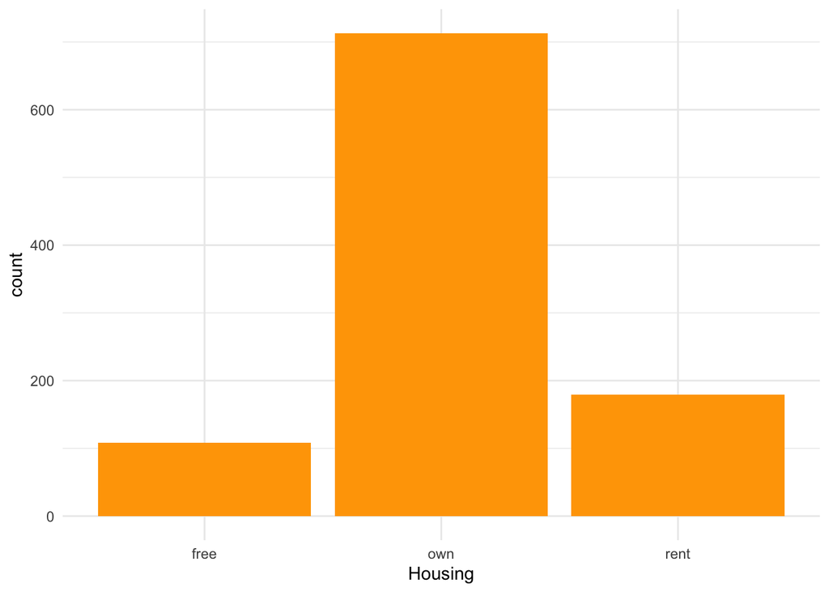

```r
ggplot(data,aes(x=Housing))+geom_bar(fill="orange")+theme_minimal()
```

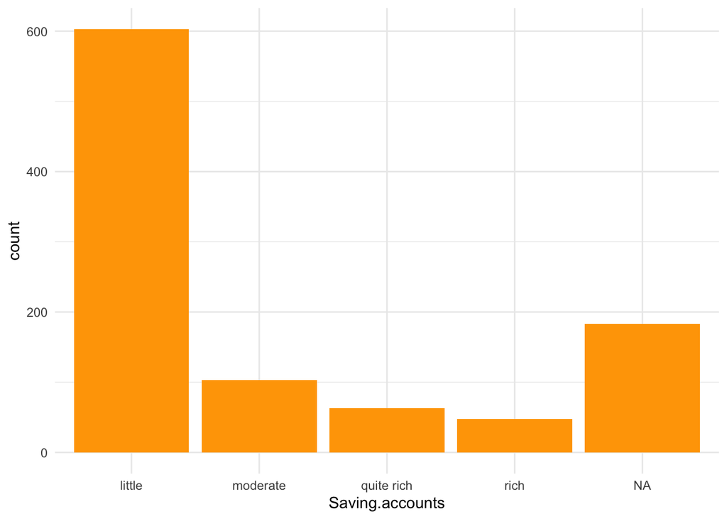

```r
ggplot(data,aes(x=Saving.accounts))+geom_bar(fill="orange")+theme_minimal()
```

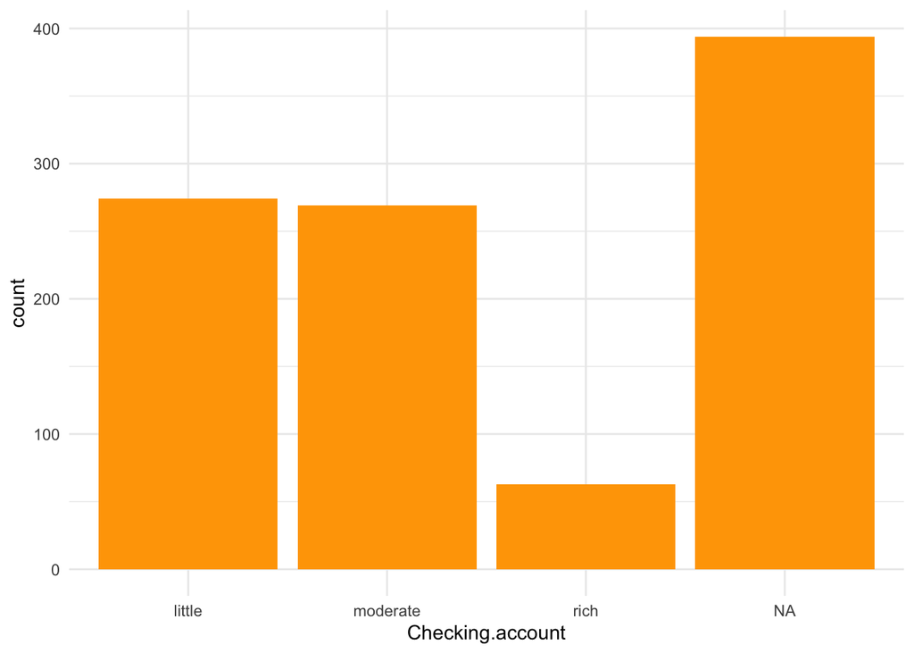

```r
ggplot(data,aes(x=Checking.account))+geom_bar(fill="orange")+theme_minimal()
```

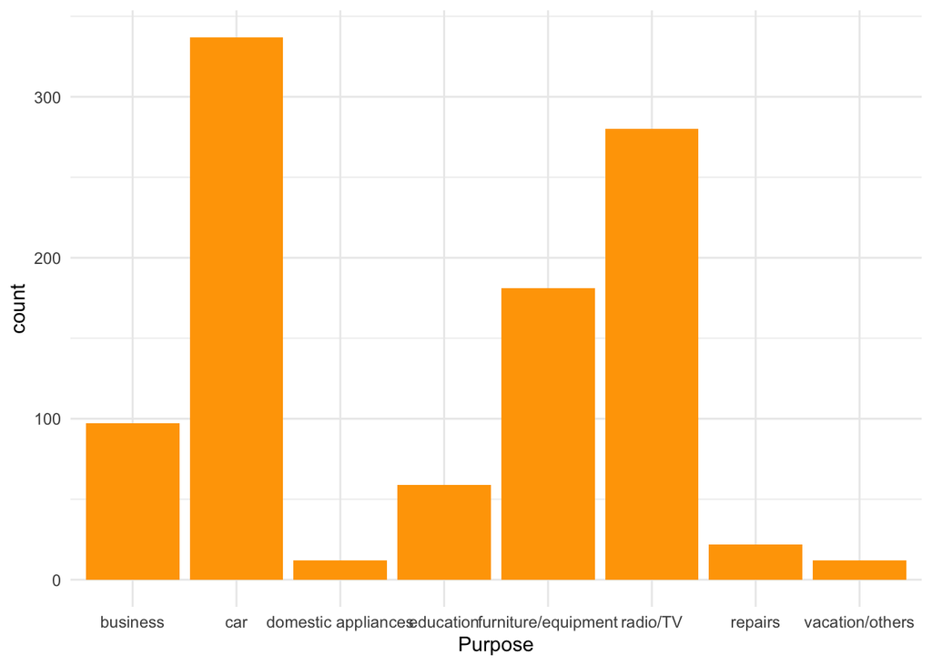

```r
ggplot(data, aes(x = Purpose)) + geom_bar(fill="orange") + theme_minimal()
```

## Correlation Analysis

This analysis simply looks at the effect one variable has on another. Here, we examine the relationship between our variables

Key:

- 1 - Deep blue = Positive correlation
- 0 - White = No correlation
- -1 - Red. = Negative Correlation
- All in-between (Teal) shows the strength

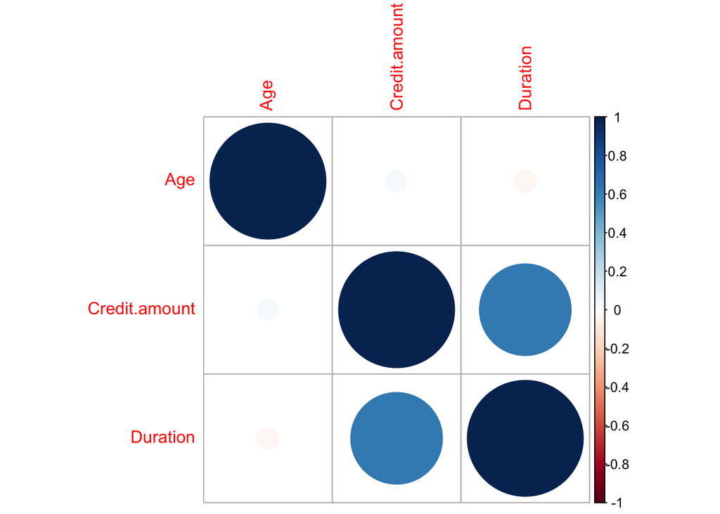

```r
numeric_data<-select(data,Age,Credit.amount,Duration)
correlation_matrix<-cor(numeric_data, use = "complete.obs")

corrplot(correlation_matrix,method = "circle")
```

### Key findings:

- Credit amount has a strong positive effect on duration.
- Age also has a positive effect on credit amount, but it’s a very weak one that might not be visible in a visualization. Let’s demonstrate this below.

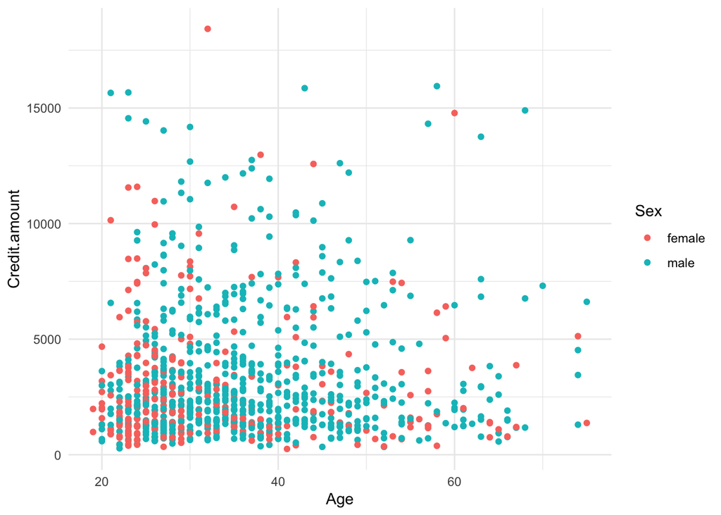

```r
ggplot(data, aes(x = Age, y = `Credit.amount`, colour = Sex)) + geom_point() + theme_minimal()
```

### Key finding

- As age increases, credit amount doesn’t. Therefore, there is no significant correlation between these variables.

## Additional Segmentation

This is based on the number of jobs our customers do and the reason why they take out credit.

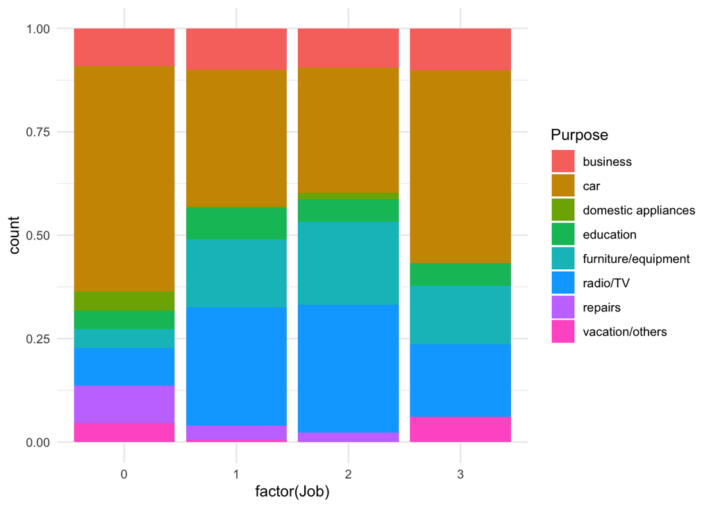

```r
ggplot(data, aes(x = factor(Job), fill = Purpose)) + geom_bar(position = "fill") + theme_minimal()
```

### Key findings

Note: Count is in percentile of the 1000 customers

- We have customers with 0 jobs. Among this group of clients, 50% or more are taking out credit to buy cars. Less than 12% are actually taking credit for business.
- You can determine the rest and make a decision as a consultant for the bank or a decision-maker for the bank.

## Risk Analysis

This is where we evaluate our credit system and determine its future.

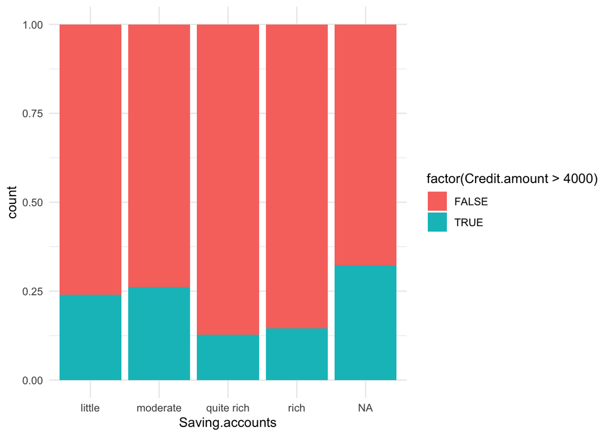

```r
ggplot(data, aes(x = Saving.accounts, fill = factor(Credit.amount > 4000))) +
  geom_bar(position = "fill") + theme_minimal()
```

### Key findings

- Customers with little in their savings accounts: up to 25% of them have credit amounts above 4000.
- There are customers whose savings accounts we cannot categorize. We need to audit the loan officers to determine what criteria qualified them for the credit. (This is the job of the auditor; I am only providing insight.)

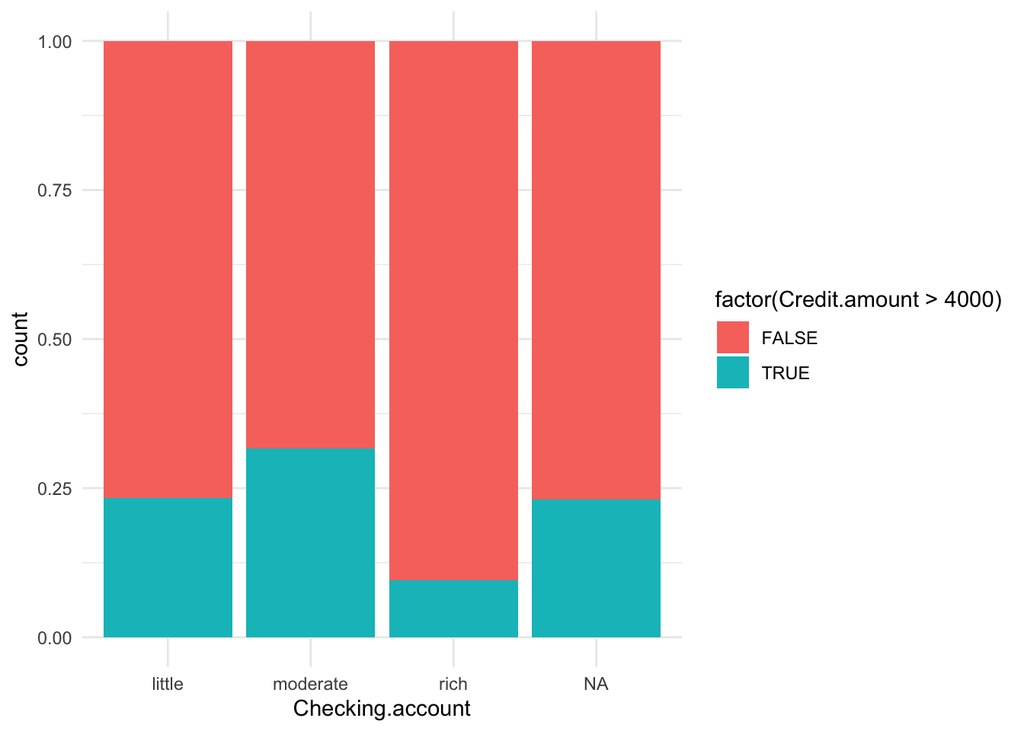

```r
ggplot(data, aes(x = Checking.account, fill = factor(Credit.amount > 4000))) +
  geom_bar(position = "fill") + theme_minimal()
```

### Key finding

We conducted the same analysis based on their checking accounts to guide us in decision-making. You can enjoy the process of discovering the information that these graphs provide for you as a business owner or manager.

## Conclusion

By performing these analyses, a bank can gain insights into customer demographics, credit behavior, and potential risks. This can help in tailoring credit products, managing risk, and optimizing marketing strategies.